# 08 Simulation and Calculating Power

18 April, 2018

## Overview

## Lesson Structure

In this session we'll cover simulation for improving our statistical inferences, with a heavy focus on power.

Specifically, we'll cover:

- simulating data in R
- simulation-based power analyses
- packages for power analysis

## Getting Started

As always, we first need to load the `tidyverse` set of packages for this Chapter.

```r
library(tidyverse)
```

## Simulating Data

We'll look at randomly sampling data that adheres to the following distributions:

- Uniform, using `runif()` (read: **r**andom **unif**orm)
- Normal, using `rnorm()` (read: **r**andom **norm**al )
- Binomial, using `rbinom()` (read: **r**andom **binom**ial)

We'll look at randomly sampling data with and without replacement, and how we can determine bias in our sampling procedure.

## The Uniform Distribution

With the uniform distribution, we sample numbers such that all values are equally likely to be drawn from our range. Try this out a few times:

```r
runif(n = 5, min = 1, max = 10)
```

```
## [1] 5.312616 2.228031 6.936071 5.586105 4.119788
```

You should get different numbers each time.

## The Uniform Distribution

You can increase the amount of numbers sampled by changing `n` to anything else.

```r
runif(n = 10, min = 1, max = 10)
```

```
##  [1] 9.299804 5.420645 6.650321 6.175965 3.015725 6.937798 1.985979
##  [8] 7.202348 9.343576 2.212575
```

Now we have 10 numbers between 1 and 10.

## The Uniform Distribution

Finally, we can change the minimum and maximum values, or the range of values we want to sample from. Try this:

```r
runif(n = 10, min = 0, max = 1)
```

```
##  [1] 0.3021164 0.7613926 0.6978638 0.4334733 0.5875973 0.5530920 0.6438522
##  [8] 0.6995444 0.8993623 0.8664777
```

## The Uniform Distribution

What happens if we calculate the mean from 10 samples from a uniform distribution? What about 100, 1000, or even 10000?

```r
runif(n = 10, min = 0, max = 1) %>% mean()
```

```
## [1] 0.6004683
```

```r
runif(n = 100, min = 0, max = 1) %>% mean()
```

```
## [1] 0.4441239
```

```r
runif(n = 1000, min = 0, max = 1) %>% mean()
```

```
## [1] 0.5032944
```

## The Uniform Distribution

With more samples, the mean better matches the mean of the sampling procedure.

Think about how this could impact your studies.

With small sample sizes, we're likely to get *skewed data that tends towards the extremes*.

## The Normal Distribution

- We can sample continuous data from the normal distribution.
- We might use this to generate data on a continuous scale with a normal distribution in the population, e.g. height and weight.
- For this, we use the `rnorm()` function.
- This provides us with a good range of values if we know (or can guess at) the mean and standard deviation of a sample from a population. Try it for the IQ test:

```r
rnorm(n = 10, mean = 100, sd = 15)
```

```
##  [1]  95.01338 100.61542 135.31231  70.55804 100.32558  82.88872  90.57213
##  [8] 103.02203 109.83342  94.33683
```

## The Normal Distribution

#### Sample Size: Larger Samples Better Match Population

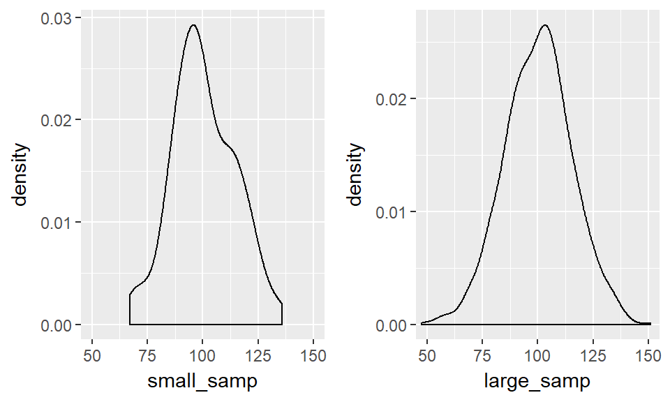

```r
set.seed(5)
small_samp <- rnorm(n = 100, mean = 100, sd = 15)
large_samp <- rnorm(n = 1000, mean = 100, sd = 15)

ggplot() + geom_density(aes(small_samp)) + coord_cartesian(x = c(50, 150))
ggplot() + geom_density(aes(large_samp)) + coord_cartesian(x = c(50, 150))
```

## The Normal Distribution

#### Standard Deviation Effects: Larger SD, more Samples Needed to Find Mean

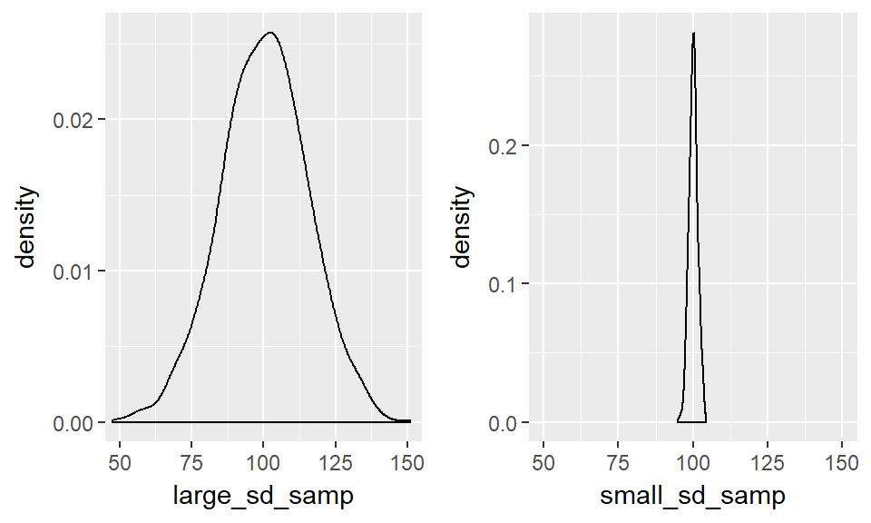

```r
set.seed(5)
large_sd_samp <- rnorm(n = 1000, mean = 100, sd = 15)
small_sd_samp <- rnorm(n = 1000, mean = 100, sd = 1.5)

ggplot() + geom_density(aes(large_sd_samp)) + coord_cartesian(x = c(50, 150))
ggplot() + geom_density(aes(small_sd_samp)) + coord_cartesian(x = c(50, 150))
```

## The Binomial Distribution

We might use this to generate data on a binomial scale, e.g. the probability of a success/failure in a task. - We sample from a binomial distribution using the `rbinom()` function. - 3 arguments: `n` (observations), `size` trials per observation, `prob` probability of success vs. failure (e.g. 0.6 = 60%)

Below, we'll get 10 observations, of 1 trial each, with a success rate of 50% on each trial.

```r
set.seed(1000)
rbinom(n = 10, size = 1, prob = 0.5)
```

```
##  [1] 0 1 0 1 1 0 1 1 0 0
```

## The Binomial Distribution

What if we want to make each observation the number of successes in 20 trials. Change the size argument to 20.

```r
set.seed(1000)
rbinom(n = 10, size = 20, prob = 0.5)
```

```
##  [1]  9 12  7 11 10  7 11 10  8  9
```

- Same 50% success rate, but each observation is out of 20 trials.

## The Binomial Distribution

Convert it to proportions, divide the whole thing by the number of trials.

```r
set.seed(1000)
rbinom(n = 10, size = 20, prob = 0.5) / 20
```

```
##  [1] 0.45 0.60 0.35 0.55 0.50 0.35 0.55 0.50 0.40 0.45
```

## The Binomial Distribution

### Removing Redundancies

Repetition of 20 in the code. Any need to repeat this? - You can make mistakes with more repetitions - …and it's harder to change your code for new cases - Avoid **magic numbers**; I know what 20 is now.

```r
# define number of trials
n_trials <- 20

set.seed(1000)
rbinom(n = 10, size = n_trials, prob = 0.5) / n_trials
```

```
##  [1] 0.45 0.60 0.35 0.55 0.50 0.35 0.55 0.50 0.40 0.45
```

- Calculate the mean of 1000 samples. Can you predict what you'll get?

## Flexible Sampling

We can randomly sample discrete variables with pre-defined probabilities. We use the same function for characters and numbers, the `sample()` function.

This is useful for creating dummy data sets where we might want to randomly sample names for participants, or outcomes with a bias on our draws.

- Define what to sample from with `x` (for integers it's all positive numbers up to the one you define)
- Define number of samples with `size`
- Define if you want to add sampled things back to the pool with `replace`

## Flexible Sampling

Try this for all numbers up to and including 10.

```r
set.seed(1000)
sample(x = 10, size = 10, replace = TRUE)
```

```
##  [1] 4 8 2 7 6 1 8 6 3 3
```

## Flexible Sampling

Did you notice how we got 3 twice? Let's change the `replace` argument to `FALSE` to see what happens.

```r
set.seed(1000)
sample(x = 10, size = 10, replace = FALSE)
```

```
##  [1]  4  7  1  5 10  8  3  2  9  6
```

Now we only get unique numbers. If we ask to draw more numbers than we have unique values, this will fail.

```r
set.seed(1000)
sample(x = 10, size = 11, replace = FALSE)
```

## Flexible Sampling

We can also sample from characters, such as when we might want to create some data for the names of participants.

```r
set.seed(1000)
names <- c("Glenn", "Nik", "Vera", "Neil")
sample(x = names, size = 2, replace = TRUE)
```

```
## [1] "Nik"  "Neil"
```

## Flexible Sampling

We can also set some pre-defined probabilities for the things we'll sample from. Let's say the probability of selecting "Glenn" is most likely in 10 draws.

```r
set.seed(1000)
names <- c("Glenn", "Nik", "Vera", "Neil")
sample(x = names, size = 10, replace = TRUE, prob = c(0.7, 0.1, 0.1, 0.1))
```

```
##  [1] "Glenn" "Vera"  "Glenn" "Glenn" "Glenn" "Glenn" "Vera"  "Glenn"
##  [9] "Glenn" "Glenn"
```

Glenn gets drawn most often because this has the highest probability to be drawn (i.e. the first in `x` is related to the first in `prob`). Let's see where this is useful…

## Sampling for Inference

We're studying a person who claims to be a psychic. We have 10 cards each with 1 of 5 symbols on the back. Can the psychic guess, above chance, which symbol is on the back of the card?

Let's simulate their data for 10 attempts.

```r
# sample the true values of the cards
set.seed(13)
psychic_outcome <- rbinom(n = 1, size = 10, prob = 0.2)

# see the true values
psychic_outcome
```

```
## [1] 3
```

## Sampling for Inference

### The Psychic

- They get it right 30% of the time but we know that on each trial the probability of a success is only 20% (i.e. 1 in 5).
- Was the psychic telling the truth, or should we have reason to doubt their claim?
- Try a binomial test, define your data, number of samples, and the probability of success.

## Sampling for Inference

### The Psychic

```r
binom.test(x = psychic_outcome, n = 10, p = 0.2)
```

```
##
##  Exact binomial test
##
## data:  psychic_outcome and 10
## number of successes = 3, number of trials = 10, p-value = 0.4296
## alternative hypothesis: true probability of success is not equal to 0.2
## 95 percent confidence interval:
##  0.06673951 0.65245285
## sample estimates:
## probability of success
##                    0.3
```

## Sampling for Inference

### The Psychic

Sample size was too small. Try 30% from 100 observations.

```r
binom.test(x = psychic_outcome * 10, n = 10 * 10, p = 0.2)
```

```
##
##  Exact binomial test
##
## data:  psychic_outcome * 10 and 10 * 10
## number of successes = 30, number of trials = 100, p-value =
## 0.01695
## alternative hypothesis: true probability of success is not equal to 0.2
## 95 percent confidence interval:
##  0.2124064 0.3998147
## sample estimates:
## probability of success
##                    0.3
```

## Sampling for Inference

### The Psychic

- One test showed that we should reject the null, the psychic guesses above chance.
- Should we trust this? We used random sampling. Maybe one study isn't enough!
- In cases where you think claims are extraordinary, it's alright to ask for extraordinary evidence!
- Maybe NHST isn't best in this case, or maybe we just need replications.

## Understanding Functions

Before we can explore the effect of replications, we need to learn a bit about functions.

User defined functions in R take the form of:

```r
function_name <- function(parameters_to_vary) {
  things_for_the_function_to_do
}
```

- Define the name as a verb (it does something).
- What will it do it to? That goes in the `()`.
- What will it do and return? That goes in the body `{}`.

## Understanding p-values and Type-I Errors

Our sampling procedure as a function:

```r
# define function name and parameters to vary
simulate_psychic_test <- function(n_trials, prob_success) {

  # sample binomial data (successs or not) for varying trials and probabilities
  psychic_outcome <- rbinom(n = 1, size = n_trials, prob = prob_success)

  # run a binomial test on the sampled data against your proability
  test <- binom.test(x = psychic_outcome, n = n_trials, p = prob_success)

  # retrieve the p-value, this is what is returned in our function
  test$p.value
}
```

## Understanding p-values and Type-I Errors

Use your new function to sample and test against the probability of success. What is your *p*-value?

```r
simulate_psychic_test(n_trials = 100, prob_success = 0.2)
```

```
## [1] 0.5322562
```

- Press play again and again, how do the *p*-values vary?

## Understanding p-values and Type-I Errors

R has a `replicate()` function which replicates whatever we ask it to do by a pre-defined number. - This takes `n` – the number of replication to carry out – plus whatever you want to replicate.

Can you predict what will happen?

```r
simulations <- replicate(n = 100,
                         simulate_psychic_test(n_trials = 100,
                                               prob_success = 0.2
                                               )
                         )
```

## Understanding p-values and Type-I Errors

```r
ggplot() +
  geom_histogram(mapping = aes(simulations),
                 binwidth = 0.05,
                 boundary = 0,
                 fill = "white",
                 colour = "black") +
  scale_x_continuous(limits = c(0, 1),
                     breaks = seq(from = 0, to = 1, by = 0.05)
                     ) +
  geom_vline(xintercept = 0.05, linetype = 2, colour = "red") +
  labs(x = "p-value") +
  theme(axis.text.x = element_text(size=6))
```

## Understanding p-values and Type-I Errors

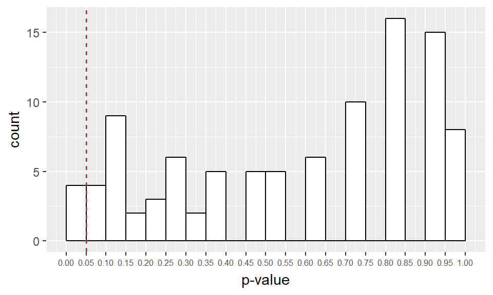

How does it look with 10,000 simulated studies?

## Understanding p-values and Type-I Errors

```r
simulations <- replicate(n = 10000,
                         simulate_psychic_test(n_trials = 100,
                                               prob_success = 0.2
                                               )
                         )
```

## Understanding p-values and Type-I Errors

```r
ggplot() +
  geom_histogram(aes(simulations),
                 binwidth = 0.05,
                 boundary = 0,
                 fill = "white",
                 colour = "black") +
  scale_x_continuous(limits = c(0, 1),
                     breaks = seq(from = 0, to = 1, by = 0.05)
                     ) +
  geom_vline(xintercept = 0.05, linetype = 2, colour = "red") +
  labs(x = "p-value") +
  theme(axis.text.x = element_text(size=6))
```

## Understanding p-values and Type-I Errors

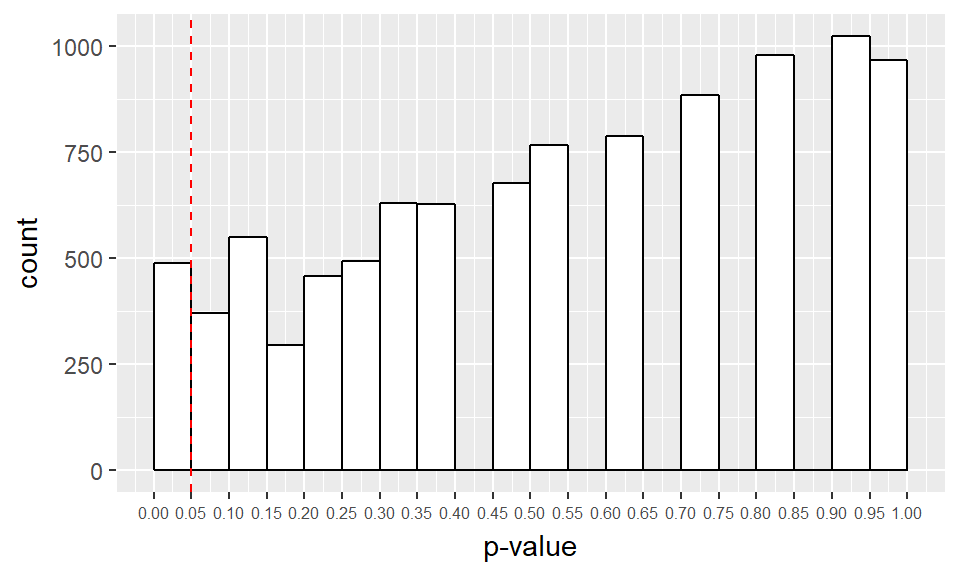

Roughly **500 studies have a *p*-value below 0.05. Thats 5% of the 10,000 studies**. You can get tiny *p*-values even when there's no true effect in the population.

## Understanding Power and Type-II Errors

Change our function so that we can give the psychic a different probability to the true probability of a success.

```r
# define function name and parameters to vary
simulate_psychic_test <- function(n_trials, prob_success, psychic_success) {

  # sample binomial data (successs or not) for varying trials and probabilities
  psychic_outcome <- rbinom(n = 1, size = n_trials, prob = psychic_success)

  # run a binomial test on the sampled data against your proability
  test <- binom.test(x = psychic_outcome, n = n_trials, p = prob_success)

  # retrieve the p-value, this is what is returned in our function
  test$p.value
}
```

## Understanding Power and Type-II Errors

Sample some data where the psychic has a bias greater than the population.

```r
true_effect_simulations <- replicate(n = 1000,
                         simulate_psychic_test(n_trials = 100,
                                               prob_success = 0.2,
                                               psychic_success = 0.25
                                               )
                         )
```

## Understanding Power and Type-II Errors

```r
ggplot() +
  geom_histogram(aes(true_effect_simulations),
                 binwidth = 0.05,
                 boundary = 0,
                 fill = "white",
                 colour = "black") +
  scale_x_continuous(limits = c(0, 1),
                     breaks = seq(from = 0, to = 1, by = 0.05)
                     ) +
  geom_vline(xintercept = 0.05, linetype = 2, colour = "red") +
  labs(x = "p-value") +
  theme(axis.text.x = element_text(size=6))
```

## Understanding Power and Type-II Errors

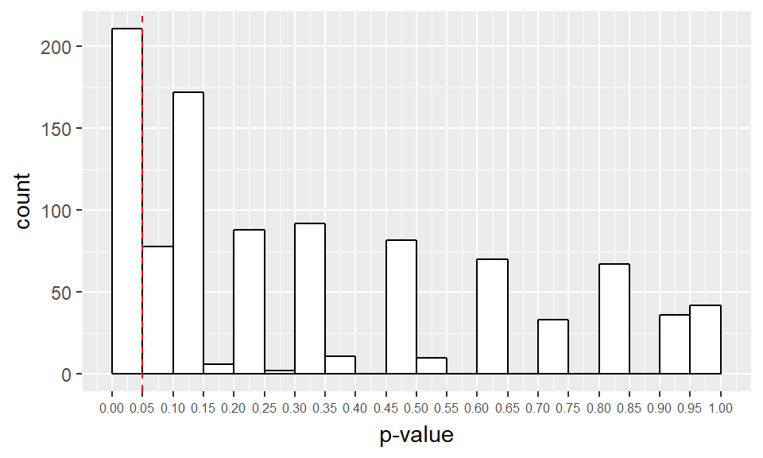

A much larger proportion of studies give us *p*-values below 0.05. Specifically, it's 211, or 21.1%.

This is the power of the study, the ability to detect a true effect. 1-power is the type-II error rate.

## Understanding Power and Type-II Errors

At only 21.1%, this is inadequate for our purposes. We generally aim for at least 80% in psychology.

Use simulation to determine trials needed for adequate power.

```r
true_effect_simulations <- replicate(n = 1000,
                         simulate_psychic_test(n_trials = 600,
                                               prob_success = 0.2,
                                               psychic_success = 0.25
                                               )
                         )
```

## Understanding Power and Type-II Errors

```r
ggplot() +
  geom_histogram(aes(true_effect_simulations),
                 binwidth = 0.05,
                 boundary = 0,
                 fill = "white",
                 colour = "black") +
  scale_x_continuous(limits = c(0, 1),
                     breaks = seq(from = 0, to = 1, by = 0.05)
                     ) +
  geom_vline(xintercept = 0.05, linetype = 2, colour = "red") +
  labs(x = "p-value") +
  theme(axis.text.x = element_text(size=6))
```

## Understanding Power and Type-II Errors

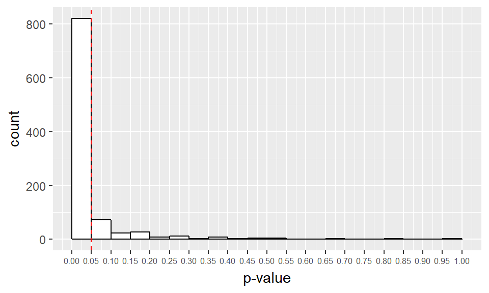

## Understanding Power and Type-II Errors

That looks better! Now, in most experiments, we'll get a *p*-value below 0.05. How many studies detected this true effect? Our power for this study is:

```r
mean(true_effect_simulations < 0.05)
```

```
## [1] 0.821
```

At 600 trials we now have an 82.1% chance to detect a true effect if present.

## Flexible Power Analyses with Simulation

### Simulation for Simple Designs

What about an IQ test against the baseline with a set mean (100) and standard deviation (15)?

```r
calculate_IQ_power <- function(n, sample_mean, sample_sd, pop_mean, pop_sd) {
  sample_data <- rnorm(n = n, mean = sample_mean, sd = sample_sd)
  test <- t.test(sample_data, mu = pop_mean, sd = pop_sd)
  test$p.value
}
```

## Flexible Power Analyses with Simulation

### Simulation for Simple Designs

Test 60 people, with a mean difference of 5 points.

```r
p_vals <- replicate(1000, calculate_IQ_power(60, 105, 15, 100, 15))
mean(p_vals < 0.05)
```

```
## [1] 0.735
```

## Flexible Power Analyses with Simulation

### Simulation for Simple Designs

Great, 73.5% power is not bad at all. Maybe we should bump up the sample size a little to get to 80%.

```r
p_vals <- replicate(1000, calculate_IQ_power(75, 105, 15, 100, 15))
mean(p_vals < 0.05)
```

```
## [1] 0.835
```

## Flexible Power Analyses with Simulation

### Simulation for Simple Designs

Around 75 participants does a good job for us. What if the standard deviation for our sample was smaller than the population?

```r
p_vals <- replicate(1000, calculate_IQ_power(20, 105, 7.5, 100, 15))
mean(p_vals < 0.05)
```

```
## [1] 0.82
```

Now it looks like we only need around 20 participants to achieve the same power.

## Flexible Power Analyses with Simulation

### Simulation for Simple Designs

What if the mean score is half as large as before?

```r
p_vals <- replicate(1000, calculate_IQ_power(70, 102.5, 7.5, 100, 15))
mean(p_vals < 0.05)
```

```
## [1] 0.793
```

Now we need more participants, even though the standard deviation is as small as before.

As you can see, sample size, effect sizes, and variance all affect the ability to detect a true effect.

## Flexible Power Analyses with Simulation

### Simulation for More Complex Designs

We can build from what we know about sampling to work for any design.

- For a *t*-test, just sample two sets of data using `rnorm()` and compare them against one another.
- But we'll look at a more complex 2 by 2 between-subjects design, which can be adapted to most scenarios.

Here, participants take part in 1 combination of 2 factors (A and B) each with 2 levels. We first have to create a tibble to hold our simulated data.

## Flexible Power Analyses with Simulation

### Simulation for More Complex Designs

```r
# how many subjects?
n <- 60

# create your design
design <- expand.grid(A = c(-.5, .5), B = c(-.5, .5))

# create table of data
data <- tibble(subject = 1: n,
               A = rep(design$A, n/4),
               B = rep(design$B, n/4)
               )
```

## Flexible Power Analyses with Simulation

### Simulation for More Complex Designs

Why pick -.5 and .5 for factor levels? Deviation coding for main effects (previous lesson)!

```r
data # look at the data
```

```
## # A tibble: 60 x 3
##    subject      A      B
##      <int>  <dbl>  <dbl>
##  1       1 -0.500 -0.500
##  2       2  0.500 -0.500
##  3       3 -0.500  0.500
##  4       4  0.500  0.500
##  5       5 -0.500 -0.500
##  6       6  0.500 -0.500
##  7       7 -0.500  0.500
##  8       8  0.500  0.500
##  9       9 -0.500 -0.500
## 10      10  0.500 -0.500
## # ... with 50 more rows
```

## Flexible Power Analyses with Simulation

### Simulation for More Complex Designs

Next, we need to set up our coefficients and error term for the linear model.

- Intercept will be 400
- A shift in Factor A to be the intercept + 30
- A shift in B to be the intercept - 50
- The interaction term to be the intercept - 40
- Finally, our error term has a mean of 0 and standard deviation of 40

## Flexible Power Analyses with Simulation

### Simulation for More Complex Designs

```r
# set up coefficients
alpha = 400
beta1 = 30
beta2 = -50
beta3 = -40
err <- rnorm(n, 0, sd = 40)

# create data from the linear model
data$y <- alpha + (beta1*data$A) + (beta2*data$B) + (beta3*data$A*data$B) + err
```

## Flexible Power Analyses with Simulation

### Simulation for More Complex Designs

Have a look at the data again, it looks like it worked!

```r
data
```

```
## # A tibble: 60 x 4
##    subject      A      B     y
##      <int>  <dbl>  <dbl> <dbl>
##  1       1 -0.500 -0.500   421
##  2       2  0.500 -0.500   472
##  3       3 -0.500  0.500   408
##  4       4  0.500  0.500   443
##  5       5 -0.500 -0.500   423
##  6       6  0.500 -0.500   479
##  7       7 -0.500  0.500   405
##  8       8  0.500  0.500   386
##  9       9 -0.500 -0.500   498
## 10      10  0.500 -0.500   428
## # ... with 50 more rows
```

## Flexible Power Analyses with Simulation

### Simulation for More Complex Designs

Check that your model fit matches the predefined coefficients. One cheat is to set the SD of the error term to a small amount to check everything worked.

## Flexible Power Analyses with Simulation

### Simulation for More Complex Designs

```r
fit <- lm(y ~ A * B, data = data)
summary(fit)
```

```
##
## Call:
## lm(formula = y ~ A * B, data = data)
##
## Residuals:
##      Min       1Q   Median       3Q      Max
## -108.540  -30.991    8.045   24.951   89.673
##
## Coefficients:
##             Estimate Std. Error t value Pr(>|t|)
## (Intercept)  401.193      5.694  70.456  < 2e-16 ***
## A             17.397     11.388   1.528   0.1322
## B            -55.695     11.388  -4.890 8.85e-06 ***
## A:B          -47.358     22.777  -2.079   0.0422 *
## ---
## Signif. codes:  0 '***' 0.001 '**' 0.01 '*' 0.05 '.' 0.1 ' ' 1
##
## Residual standard error: 44.11 on 56 degrees of freedom
## Multiple R-squared:  0.3532, Adjusted R-squared:  0.3185
## F-statistic: 10.19 on 3 and 56 DF,  p-value: 1.868e-05
```

## Flexible Power Analyses with Simulation

### Simulation for More Complex Designs

You might want to put all of this in a big loop to sample data, refit your model, and capture *p*-values to calcualte power.

But, that's costly in R compared to using inbuilt functions.

One workaround is to fit a model on your dummy data once, then use the `simulate()` function on your fitted model object.

We'll do this, but we want to make it into a function first!

## Flexible Power Analyses with Simulation

### Simulation for More Complex Designs

Extracting coefficients, like *p*-values, from linear models can be a pain in R. Different models have different titles, and it's all stored in a big, unwieldy list.

Try running `str()` on both **fit** and **tidy_table** to see what I mean…

```r
tidy_table <- broom::tidy(fit)
tidy_table
```

```
##          term  estimate std.error statistic      p.value
## 1 (Intercept) 401.19267  5.694205 70.456313 2.278225e-56
## 2           A  17.39678 11.388409  1.527587 1.322442e-01
## 3           B -55.69488 11.388409 -4.890488 8.854745e-06
## 4         A:B -47.35847 22.776819 -2.079240 4.218676e-02
```

## Flexible Power Analyses with Simulation

### Simulation for More Complex Designs

- This function takes your dummy data and a model fitted to that data.
- It then makes a new copy of your data and simulates the outcome variable.
- After that, it fits your model, before extracting the *p*-value (more on `broom::tidy()` in later lessons).
- Note that we only get the effect for the 4th coefficient, the interaction.

## Flexible Power Analyses with Simulation

### Simulation for More Complex Designs

```r
simulate_model_fit <- function(data, model_fit) {
  # simulate data and add to tibble
  new_data <- mutate(data, sim_y = simulate(fit)$sim_1)

  # refit model
  refit_model <- lm(sim_y ~ A * B, data = new_data)

  # extract p-value for interaction
  broom::tidy(refit_model)$p.value[4]
}
```

## Flexible Power Analyses with Simulation

### Simulation for More Complex Designs

Simply use replicate on your function with your data and fitted model to get the power.

```r
complex_power <- replicate(1000, simulate_model_fit(data, fit))
mean(complex_power < .05)
```

```
## [1] 0.529
```

## Performing Power Analyses from Packages

There are packages for calculating power without all this hassle. So why simulate?

- Simulation is flexible, so you can get it to work for any design (and for any type of effect; main effect, interaction only, both?)
- So far, no method except for simulation for linear mixed effects models
- Makes you consider your data structure first, spotting design mistakes early

## Performing Power Analyses from Packages

For traditional analyses, there's a good number of ways to calculate power without simulation, e.g.:

- `power.t.test()` for *t*-tests
- `power.anova.test()` for ANOVAs

Let's see how the ANOVA function works, and you can work back to the *t*-test function if necessary.

## Performing Power Analyses from Packages

In this function, define the number of groups, and number of observations (typically participants) per group. Define the variance for the within and between subjects factors.

## Performing Power Analyses from Packages

Making the below assumptions, it looks like our study is overpowered.

```r
power.anova.test(groups = 4, n = 20, between.var = 1, within.var = 3)
```

```
##
##      Balanced one-way analysis of variance power calculation
##
##          groups = 4
##               n = 20
##     between.var = 1
##      within.var = 3
##       sig.level = 0.05
##           power = 0.9679022
##
## NOTE: n is number in each group
```

## Performing Power Analyses from Packages

Alternatively, we can set our desired power (typically 80% in psychology), and this will work out the number of participants needed per group.

```r
power.anova.test(groups = 4, between.var = 1, within.var = 3, power = .80)
```

```
##
##      Balanced one-way analysis of variance power calculation
##
##          groups = 4
##               n = 11.92613
##     between.var = 1
##      within.var = 3
##       sig.level = 0.05
##           power = 0.8
##
## NOTE: n is number in each group
```

We only need 12 people in each group to achieve a power of 80% (this is rare in my research area).

## Performing Power Analyses from Packages

There are other options which allow you to specify means or effect sizes to determine power, and as such these may be more user friendly.

One option is the `pwr` package, which contains a number of functions for calcualting power with different designs.

Have a look at this in your own time to see if it will be useful to you.